## 1. Выбор данных

https://vincentarelbundock.github.io/Rdatasets/datasets.html - здесь есть множество разных датасетов с описанием. При этом можно предварительно посмотреть на количество наблюдений, количество признаков, сколько из них являются факторами и т.д.

## 2. Считывание и просмотр

```r
df <- read.csv(file = "Angell.csv", header = TRUE, as.is = FALSE) #Скачиваем csv, сохраняем в папку, где лежит r markdown и считываем данные.
head(df) #Head() Показывает первые шесть строк данных.
```

```
##            X moral hetero mobility region
## 1  Rochester  19.0   20.6     15.0      E
## 2   Syracuse  17.0   15.6     20.2      E
## 3  Worcester  16.4   22.1     13.6      E
## 4       Erie  16.2   14.0     14.8      E
## 5  Milwaukee  15.8   17.4     17.6     MW
## 6 Bridgeport  15.3   27.9     17.5      E
```

## 3. Описание данных

Рассматриваемые данные содержат различную информацию о 43 городах в Америке около 1950г.

moral - Moral integration - Composite of crime rate and welfare expenditures

hetero - Ethnic Heterogenity - From percentages of nonwhite and foreign-born white residents

mobility - Geographic Mobility - From percentages of residents moving into and out of the city

region - A factor with levels: E Northeast; MW Midwest; S Southeast; W West.

## 4. Типы признаков

moral - количественный hetero - количественный mobility - количественный region - качественный

```r
library(dplyr)
summarize(df, across(moral:region, function(x) max(table(x)))) #считает сколько раз встречается мода у каждого признака
```

```
##   moral hetero mobility region
## 1     2      1        2     14
```

```r
#df %>% summarize(across(moral:region, function(x) max(table(x)))) #считает сколько раз встречается мода у каждого признака
```

Из таблицы выше можем заключить, что hetero - абсолютно непрерывный признак. Кроме того, можем считать, что moral и mobility ближе к непрерывным признакам.

## 5. Порядковые признаки

Здесь необходимо проверить соответствие текстовых меток порядкового признака (если такие использованы) их естественному порядку.  
В данном датасете таких признаков нет.

## 6. Matrix plot, outliers, etc.

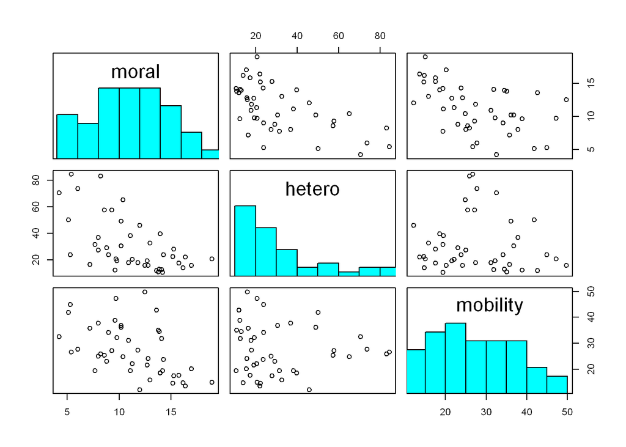

```r
panel.hist <- function(x, ...) #функция рисующая гистограмму, предлагаемая в help'е функции pairs
{
    usr <- par("usr"); on.exit(par(usr))
    par(usr = c(usr[1:2], 0, 1.5) )
    h <- hist(x, plot = FALSE)
    breaks <- h$breaks; nB <- length(breaks)
    y <- h$counts; y <- y/max(y)
    rect(breaks[-nB], 0, breaks[-1], y, col = "cyan", ...)
}

pairs(df[,2:4], diag.panel = panel.hist)
```

Для категоризованной картинки используйте функцию ggpairs

## 7. Симметричность распределений.

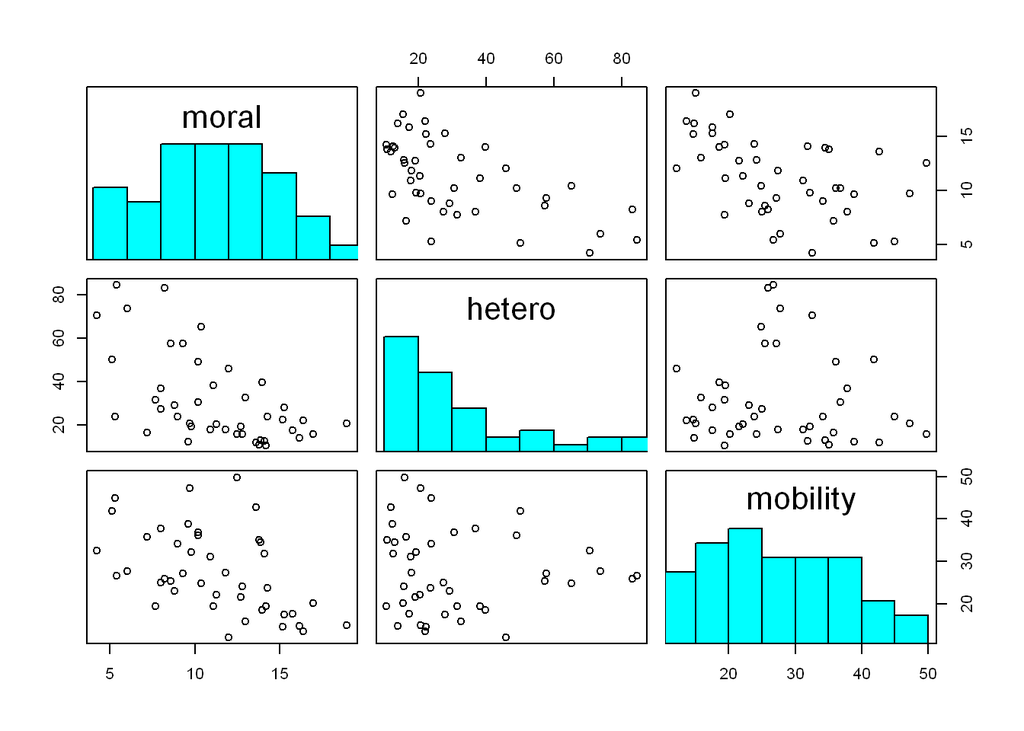

```r
dfl <- transform(df, hetero=log(hetero))

pairs(df[,2:4], diag.panel = panel.hist)
```

## 8. Аутлаеры

В данном случае на одном скаттерплоте (hetero & moral) видна линейная зависимость, не имеющая аутлаеров относительно нее. На скаттерплоте (mobility & hetero) отсутствует зависимость и, соответственно, аутлаеры. На (moral & mobility) также линейная зависимость, но вместо аутлаеров наблюдается скорее неоднородность.

## 10. Матрикс плот и аутлаеры для отдельной группы.

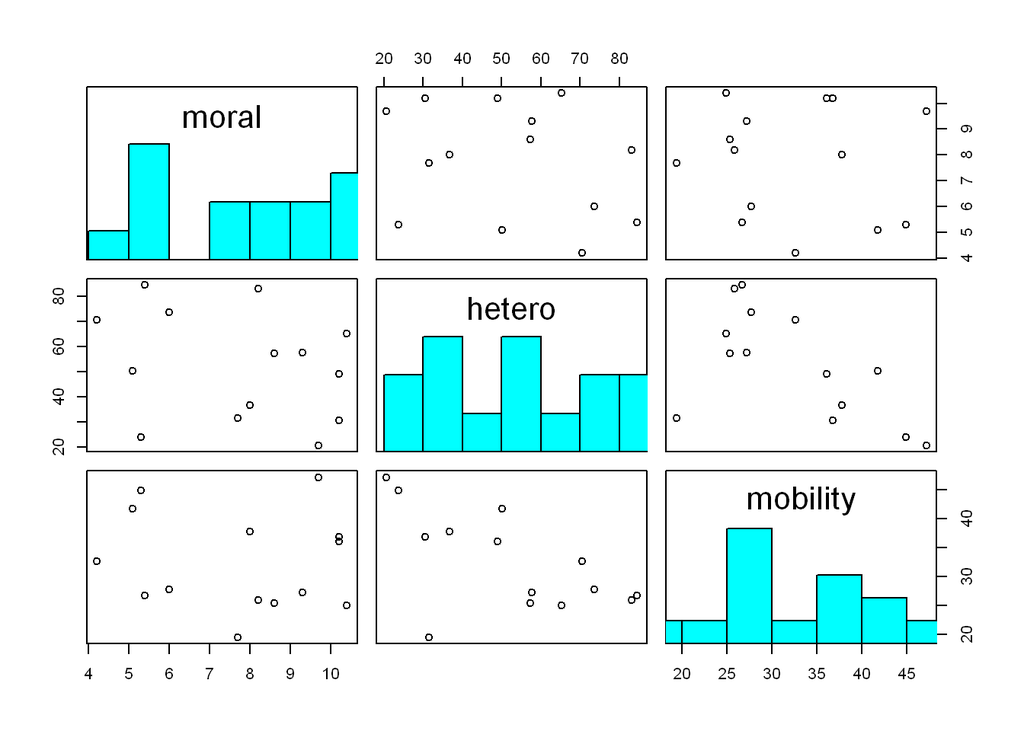

```r
pairs(df[df$region == "S",2:4], diag.panel = panel.hist)
```

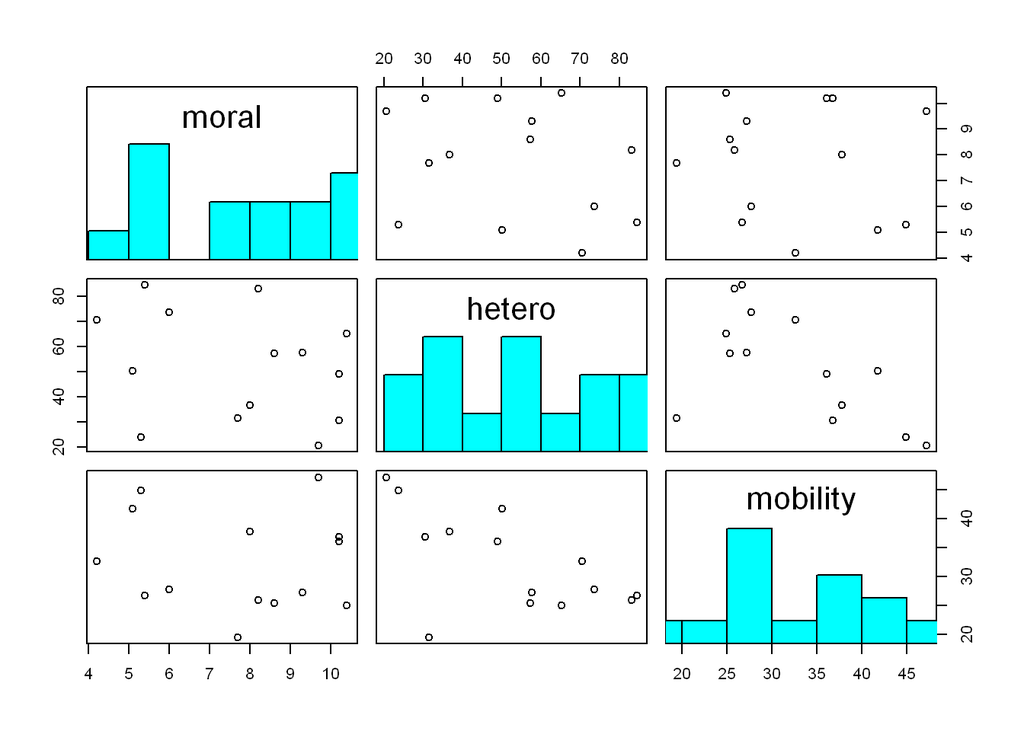

```r
dflo <- dfl #сохраняем датасет
dflo[38,] <- NA #удаляем аутлаер относительно линейной зависимости между hetero и mobility
pairs(df[df$region == "S",2:4], diag.panel = panel.hist)
```

## 11. Descriptive statistics

```r
summary(df)
```

```
##           X          moral           hetero         mobility     region
##  Akron     : 1   Min.   : 4.20   Min.   :10.60   Min.   :12.10   E : 9
##  Atlanta   : 1   1st Qu.: 8.70   1st Qu.:16.90   1st Qu.:19.45   MW:14
##  Baltimore : 1   Median :11.10   Median :23.70   Median :25.90   S :14
##  Birmingham: 1   Mean   :11.20   Mean   :31.37   Mean   :27.60   W : 6
##  Bridgeport: 1   3rd Qu.:13.95   3rd Qu.:39.00   3rd Qu.:34.80
##  Buffalo   : 1   Max.   :19.00   Max.   :84.50   Max.   :49.80
##  (Other)   :37
```

```r
summary(dfl)
```

```
##           X          moral           hetero         mobility     region
##  Akron     : 1   Min.   : 4.20   Min.   :2.361   Min.   :12.10   E : 9
##  Atlanta   : 1   1st Qu.: 8.70   1st Qu.:2.827   1st Qu.:19.45   MW:14
##  Baltimore : 1   Median :11.10   Median :3.165   Median :25.90   S :14
##  Birmingham: 1   Mean   :11.20   Mean   :3.267   Mean   :27.60   W : 6
##  Bridgeport: 1   3rd Qu.:13.95   3rd Qu.:3.663   3rd Qu.:34.80
##  Buffalo   : 1   Max.   :19.00   Max.   :4.437   Max.   :49.80
##  (Other)   :37
```

```r
library(moments)
summarize(dfl, across(moral:mobility, list(kurtosis = kurtosis, skewness = skewness)))
```

```
##   moral_kurtosis moral_skewness hetero_kurtosis hetero_skewness
## 1       2.295829    -0.01912821        2.158586       0.4273672
##   mobility_kurtosis mobility_skewness
## 1          2.303007         0.4120319
```

## 2.1 Выбор категоризующей переменной

В качестве категоризующего признака возьмем region. Сравнивать будем центральные штаты и юго-восточный регион, как имеющие наибольшее количество наблюдений (14 и 13, соответственно).

## 2.2 Boxplot

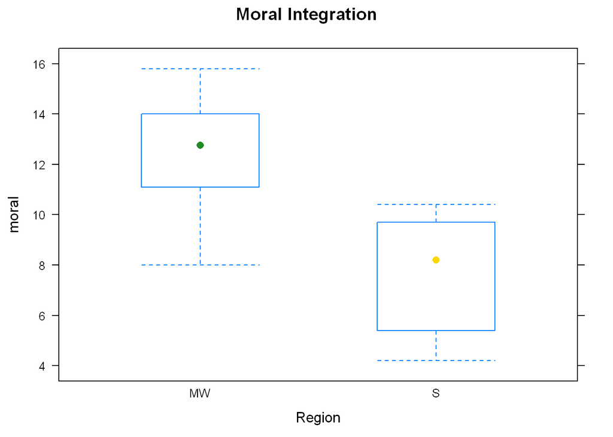

```r
dfcomp <- dflo %>% filter(region == "S" | region == "MW") #Выбираем из дата фрейма только наблюдения из юго-восточного и центрального регионов. Filter - вытаскивает подвыборку дата фрейма. %>% - передает dflo как первый параметр функции, идущей после этого знака.
dfcomp$region <- droplevels(dfcomp$region) #Изменяет параметр-фактор, отвечающий за принадлежность городу региона, оставляя только присутствующие регионы (в нашем случае юго-восточный и центральный)
library(lattice)
bwplot(moral ~ region, data = dfcomp, col = c("forestgreen", "gold"), main = "Moral Integration", xlab = "Region") #строим боксплоты моральной интеграции по региону. moral ~ region - моральная интеграция как главный параметр, ~ region - разбивает боксплоты на группы в зависимости от региона. data - передаем наш дата фрейм. col - раскрашивает боксплоты в зависимости от группы. main - название над картинкой. xlab - подпись оси х.
```

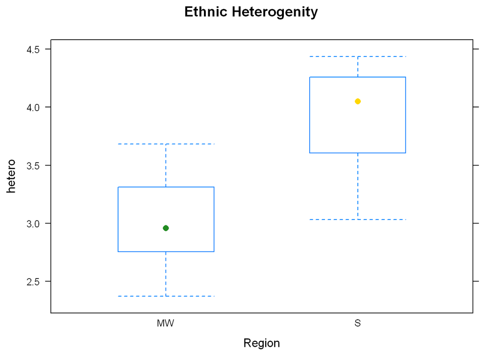

```r
#Далее, аналогичные картинки относительно двух других признаков.

bwplot(hetero ~ region, data = dfcomp, col = c("forestgreen", "gold"), main = "Ethnic Heterogenity", xlab = "Region")
```

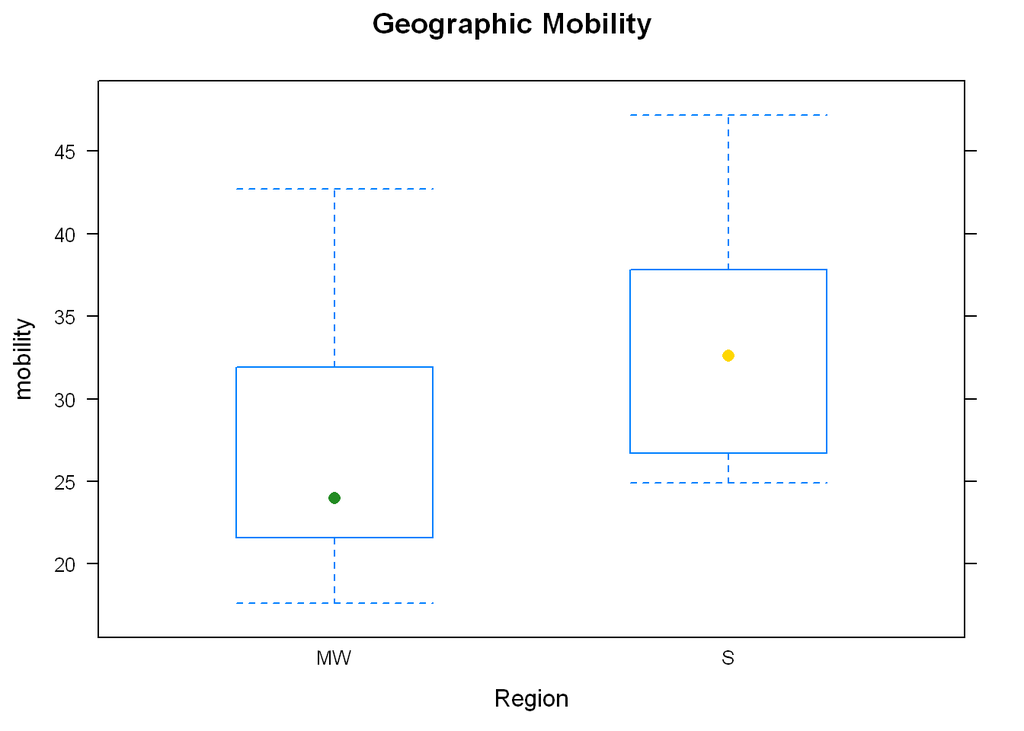

```r
bwplot(mobility ~ region, data = dfcomp, col = c("forestgreen", "gold"), main = "Geographic Mobility", xlab = "Region")
```

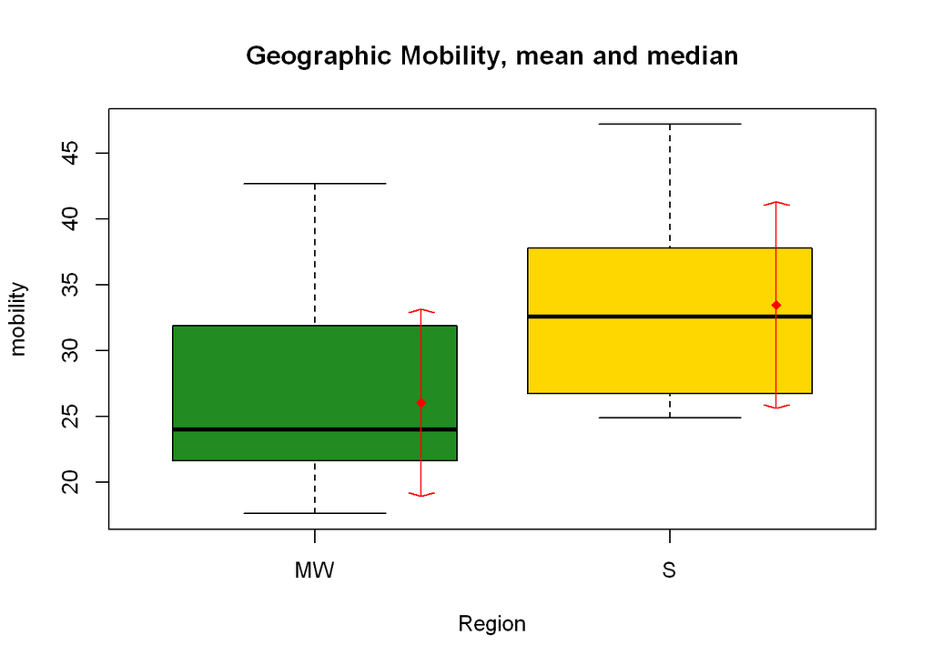

```r
#boxplot(mobility ~ region, dfcomp, col = c("forestgreen", "gold"), main = "Geographic Mobility, mean and median", xlab = "Region")
rb<- boxplot(mobility ~ region, dfcomp, col = c("forestgreen", "gold"), main = "Geographic Mobility, mean and median", xlab = "Region")
#title("Comparing boxplot()s and non-robust mean +/- SD")
mn.t <- tapply(dfcomp$mobility, dfcomp$region, mean)
sd.t <- tapply(dfcomp$mobility, dfcomp$region,sd)
xi <- 0.3 + seq(rb$n)
points(xi, mn.t, col = "red", pch = 18)
arrows(xi, mn.t - sd.t, xi, mn.t + sd.t,
       code = 3, col = "red", angle = 75, length = .1)
```

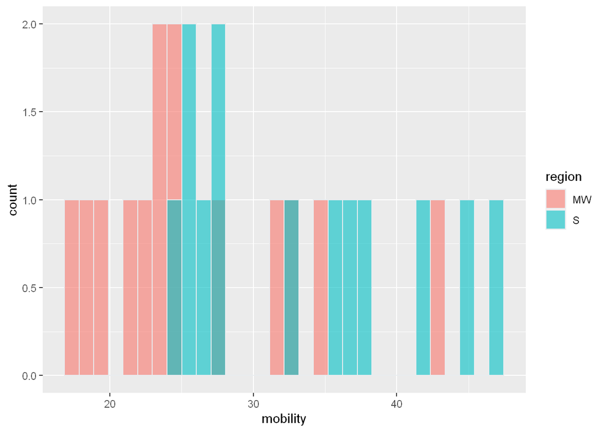

```r
#две гистограммы рядом
library(ggplot2)
ggplot(dfcomp, aes(x=mobility, fill=region)) +
  geom_histogram( color='#e9ecef', alpha=0.6, position='identity')
```